# RNAseq Example

Dayna Devit

# RNA-seq analysis

Summary

This project shows the RNAseq data processing of tipically developed children vs children with ASD condition. Only 2 replicates per sample were analyzed. The original study used 13 ASD and 13 control samples and integrated transcriptomic and proteomic data. In this repository, only a subset of RNA-seq samples was analyzed to demonstrate the computational workflow. Consequently, the differential expression and enrichment results are not expected to exactly reproduce the published biological conclusions.

Aim: To demonstrate a reproducible RNA-seq differential expression analysis workflow using publicly available Autism Spectrum Disorder (ASD) serum RNA-seq data.

**Datasets:**

RNA-seq data were obtained from the publicly available dataset generated by Author Ziyun Li et al. (2025), available through the Gene Expression Omnibus (GEO accession GSE317721). Link to the dataset: https://www.ncbi.nlm.nih.gov/geo/query/acc.cgi?acc=GSE317721

The samples were obtained from NCBI GEO Sample GSM9477131 bioproject PRJNA1415094

- *ASD 1=SRR36999782*
- ASD 2=SRR36999779
- *TD 1=SRR36999767*
- TD 2=SRR36999760

According to the study, the samples belong to typically developing (TD) children and children with Autism Spectrum Disorder (ASD). The samples were obtained from the participants serum.

##### **Workflow**

##### ▼ Public RNA-seq dataset

##### ▼ Count matrix

##### ▼ Quality control

##### (PCA, sample distances, dispersion)

##### ▼ Differential expression (DESeq2)

##### ▼ Visualization (MA plot, Volcano plot)

##### ▼ Functional enrichment

##### (GO BP, CC, MF; KEGG)

##### ▼ Biological interpretation

##### Conclusion

##### **Methods**

Datasets were downloaded from NCBI GEO Sample GSM9477131 bioproject PRJNA1415094

The data manipulation and software use was done through Bash shell. The Software Version used were the following: FastQC 0.12.1 fastp 0.23.4 bwa 0.7.17-r1188 featureCounts 2.0.6 cufflinks 2.2.1 stringtie 2.2.1 R 4.6.0 DESeq2 1.46.0.

Differential expression analysis was performed using the DESeq2 Bioconductor package. Genes with an adjusted *p*-value < 0.05 and an absolute log₂ fold change greater than 1 were considered significantly differentially expressed.

The following plots were produced in R: CA, MA plot, Volcano plot, Dot plots, Enrichment maps.

**Working through Bash Shell**

Software needed

```{bash} #!bin/bash sudo apt update sudo apt install fastqc sudo apt install fastp sudo apt install bwa

sudo apt update sudo apt install subread sudo apt install featureCounts sudo apt-get install build-essential autoconf automake libtool pkg-config # sudo apt install cufflinks #if Cufflinks doesn’t install that way, the easiest way for me was to download it and export the PATH to install it wget http://cole-trapnell-lab.github.io/cufflinks/assets/downloads/cufflinks-2.2.1.Linux_x86_64.tar.gz tar zxvf cufflinks-2.2.1.tar.gz cd cufflinks-2.2.1.Linux_x86_64/ export PATH=$PATH:~/cufflinks-2.2.1.Linux_x86_64 echo 'export PATH=$PATH:~/cufflinks-2.2.1.Linux_x86_64’ >> ~/.bashrc

#This is needed for the use and installation of R packages sudo apt-get update sudo apt install  
libcairo2-dev  
libfreetype6-dev  
libfontconfig1-dev  
libharfbuzz-dev  
libfribidi-dev  
pkg-config sudo apt update #For the use of DESeq2 in R, this need to be pre-installed in Linux sudo apt install -y  
build-essential  
r-base-dev  
libcurl4-openssl-dev  
libssl-dev  
libxml2-dev  
zlib1g-dev

````
Download Reference Genome

```{bash}

sudo apt update
curl -o datasets 'https://ftp.ncbi.nlm.nih.gov/pub/datasets/command-line/v2/linux-amd64/datasets'
curl -o dataformat 'https://ftp.ncbi.nlm.nih.gov/pub/datasets/command-line/v2/linux-amd64/dataformat'
chmod +x datasets dataformat

#Download ref genome and GTF file in a zip file
./datasets download genome accession GCF_000001405.40 --include genome,gtf
unzip ncbi_dataset.zip

# Access the files, you should have GCF_000001405.40_GRCh38.p14_genomic.fna and genomic.gtf
cd ncbi_dataset/ncbi_dataset/data/GCF_000001405.40
#Rename the fasta file for an easier name to call
mv GCF_000001405.40_GRCh38.p14_genomic.fna hsa_fasta.fna

# Move the files to the working folder for their use (you can put the working directory instead of the "../"
 mv hsa_fasta.fna ../../../../
 mv genomic.gtf ../../../../
 cd ../../../../
 chmod a+rwx hsa_fasta.fna
 chmod a+rwx genomic.gtf
````

Download of samples

```{bash} #Download of public datasets used for this workflow #Control samples wget -nc ftp://ftp.sra.ebi.ac.uk/vol1/fastq/SRR369/060/SRR36999760/SRR36999760_2.fastq.gz wget -nc ftp://ftp.sra.ebi.ac.uk/vol1/fastq/SRR369/060/SRR36999760/SRR36999760_1.fastq.gz wget -nc ftp://ftp.sra.ebi.ac.uk/vol1/fastq/SRR369/067/SRR36999767/SRR36999767_1.fastq.gz wget -nc ftp://ftp.sra.ebi.ac.uk/vol1/fastq/SRR369/067/SRR36999767/SRR36999767_2.fastq.gz

#ASD samples wget -nc ftp://ftp.sra.ebi.ac.uk/vol1/fastq/SRR369/079/SRR36999779/SRR36999779_1.fastq.gz wget -nc ftp://ftp.sra.ebi.ac.uk/vol1/fastq/SRR369/079/SRR36999779/SRR36999779_2.fastq.gz wget -nc ftp://ftp.sra.ebi.ac.uk/vol1/fastq/SRR369/082/SRR36999782/SRR36999782_1.fastq.gz wget -nc ftp://ftp.sra.ebi.ac.uk/vol1/fastq/SRR369/082/SRR36999782/SRR36999782_2.fastq.gz

#TD 1=SRR36999767 #TD 2=SRR36999760 #ASD 1=SRR36999782 #ASD 2=SRR36999779

````
**QC**

```{bash}
fastqc SRR36999767_1.fastq.gz
fastqc SRR36999767_2.fastq.gz
fastqc SRR36999760_1.fastq.gz
fastqc SRR36999760_2.fastq.gz
fastqc SRR36999779_1.fastq.gz
fastqc SRR36999779_2.fastq.gz
fastqc SRR36999782_1.fastq.gz
fastqc SRR36999782_2.fastq.gz
#The docs showed the sequences were already trimmed and had already been through a QC process.
# fastp was not used. If your sequences need further QC use
# fastp SRR36999767_1.fastq.gz
# fastp SRR36999767_2.fastq.gz
# with all the sequences individually.
````

**Data quality Inspection**

The datasets were downloaded in FASTQ format. However, after inspecting the quality using fastqc, it was noticed the data was cleaned. The description of the datasets mention they used fastp to clean it from connectors, low-quality Reads, until obtaining high quality sequences for further analysis.

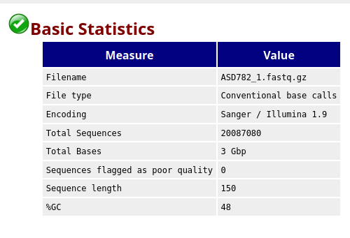

The first table shows the data from the fastq file, the name, total of sequences, sequencer used, sequence length. Note that:

- There are no sequences flagged as poor quality.
- The sample shows 48 %GC content. (“typical mean” GC content 45–55%)

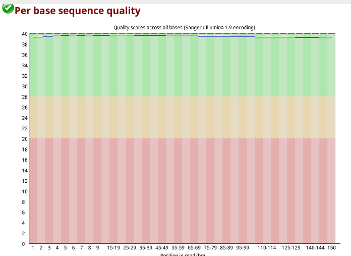

All the sequences quality score is good, >25.

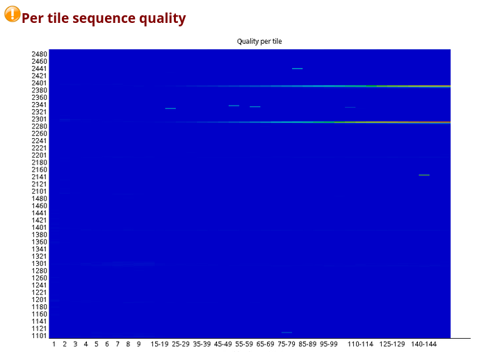

This graph is focused on showing us if there is a loss in quality associated with only one part of the flowcell. Overall, there is no major issues found.

Some common issues are:

- bubbles going through the flowcell
- smudges on the flowcell
- debris inside the flowcell lane.
- overloaded flowcell

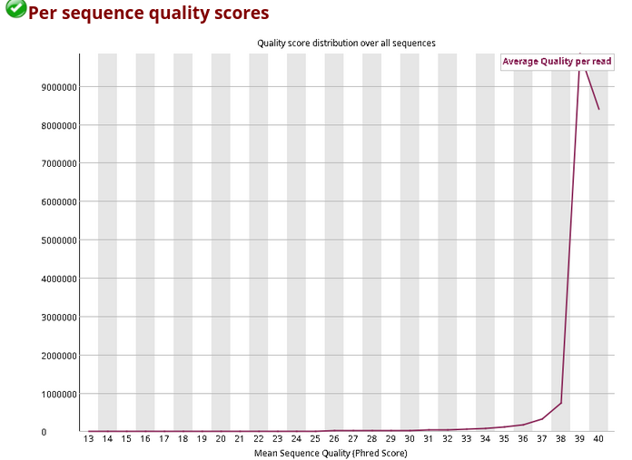

  For what was shown before, we know that all sequences have high quality score. However, in the case there were sequences with low QC this graph depicts if there is a subset of the sequences that have universally low quality values.

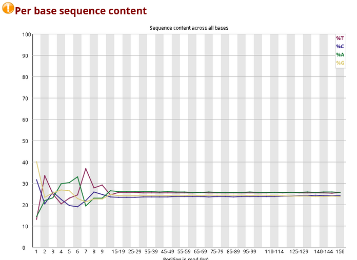

In this graph we have to look at little to no difference between the different bases of a sequence run, so the lines in this plot should run parallel with each other. However, in RNAseq data is normal to find bias in the positions at which reads start.

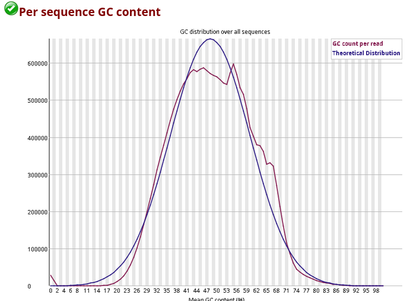

Overall, it tends to follow the normal distribution

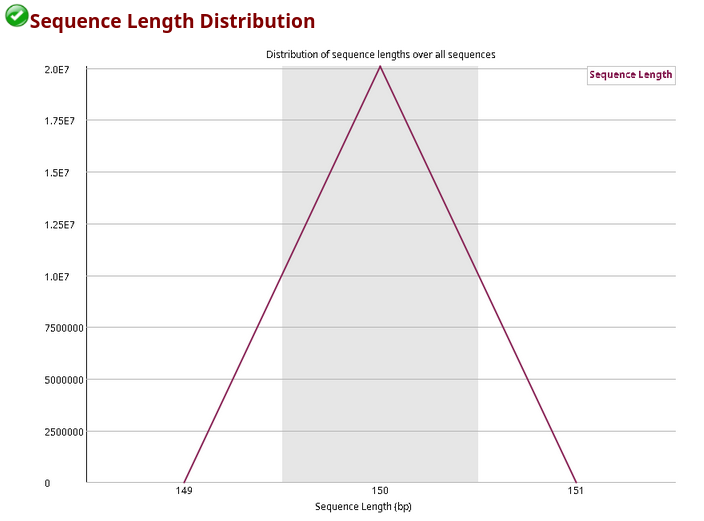

There is not variation of sequences’ lenght.

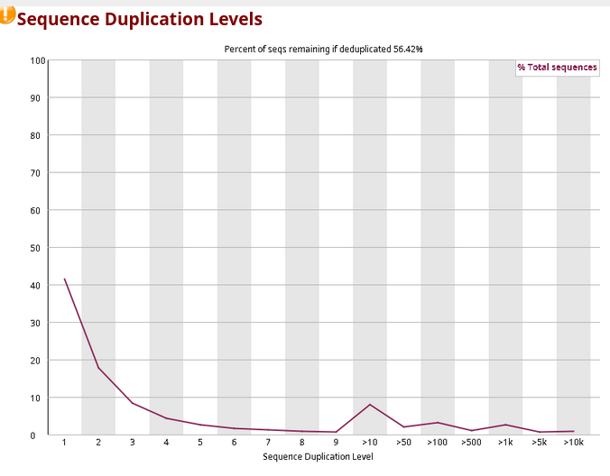

Since 56.42% of sequences remain after deduplication, 43.6%of reads are duplicates. Around 40% of reads occur only once, and there is a noticeable fraction of reads that occur many times (>10×), producing the secondary peak. SInce this is RNA-seq, we would expect to have many identical reads.

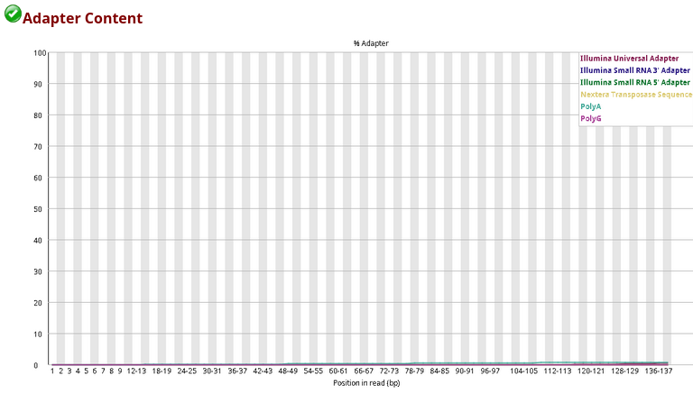

There is no adapter content. There is no need for further trimming.

Pre-alignment

This step is to obtain the reference genome and GTF file from NCBI.

```{bash} # Obtaining Ref genome and GTF file #We are using curl to download the ref genome and GTF file. Curl was previously installed.

sudo apt update curl -o datasets ‘https://ftp.ncbi.nlm.nih.gov/pub/datasets/command-line/v2/linux-amd64/datasets’ curl -o dataformat ‘https://ftp.ncbi.nlm.nih.gov/pub/datasets/command-line/v2/linux-amd64/dataformat’ chmod +x datasets dataformat

#Download ref genome and GTF file in a zip file ./datasets download genome accession GCF_000001405.40 –include genome,gtf unzip ncbi_dataset.zip

#Access the files, you should have GCF_000001405.40_GRCh38.p14_genomic.fna and genomic.gtf cd ncbi_dataset/ncbi_dataset/data/GCF_000001405.40 #Rename the fasta file for an easier name to call mv GCF_000001405.40_GRCh38.p14_genomic.fna hsa_fasta.fna

#Move the files to the working folder for their use (you can put the working directory instead of the “../” mv hsa_fasta.fna ../../../../ mv genomic.gtf ../../../../ cd ../../../../ chmod a+rwx hsa_fasta.fna chmod a+rwx genomic.gtf

````
# **Alignment, Sort and index**

This example used bwa and samtools. You can notice that both sequences 1 and 2 (paired) are used to align with the ref genome.

```{bash}
bwa mem Homo_sapiens.fna SRR36999760_1.fastq.gz SRR36999760_2.fastq.gz > youralignedsequece.bam
#Sort
samtools sort youralignedsequece.bam -o sortedaligned.bam
#Index
samtools index sortedaligned.bam
````

**Read Counts.**

For this step we use featureCounts. It’ll give us a file with the number of reads that map each gene. These raw counts are ideal for differential expression analysis because DESeq2 model counts data directly.

```{bash} #Readcount generation #You should already have subread and featureCounts softwares #counts760 heere is the output file I wanted to create sudo apt update

featureCounts -a genomic.gtf -o counts760.txt sortedaligned760.bam –maxMOp 50 -p –countReadPairs -T 10

````
**Pre-visualization step**

For this step we need to build a matrix that contains the TD and ASD gene counts. I used bash to gather all the information together in a same matrix.

```{bash}
## This file contains
# *The gene IDs (first column)
#  The dataset numbers (first row) and their gene counts generated by featurecounts

awk '{print $1, $NF}' counts760.txt > f1
awk '{print $1, $NF}' counts767.txt > f2
awk '{print $1, $NF}' counts779.txt.txt > f3
awk '{print $1, $NF}' counts782.txt > f4
paste <(cut -d' ' -f1 f1) <(cut -d' ' -f2 f1) <(cut -d' ' -f2 f2) <(cut -d' ' -f2 f3) <(cut -d' ' -f2 f4) >> ASDvsTD_CountsF.txt

head ASDvsTD_CountsF.txt
````

**Continue in R**

# Differential expression Analysis

We are proceeding with deseq2 which will help us perform the differential expression analysis.

```{r} if (!requireNamespace(“BiocManager”, quietly = TRUE)) install.packages(“BiocManager”) BiocManager::install(“DESeq2”)

library(DESeq2)

setwd(“your folder pathway”)

ASDvsTD <- read.table(“ASDvsTD_CountsF.txt”, row.names = 1, header = TRUE) metadata <- read.table(“metadata.txt”, row.names = 1, header = TRUE) # Ensure sample names match all(colnames(ASDvsTD) == rownames(metadata)) metadata$type <- factor(metadata$type) dds <- DESeqDataSetFromMatrix(countData = ASDvsTD, colData = metadata, design = ~ type) # replace ‘condition’ with your variable # It should say “true”

dds <- DESeq(dds) res <- results(dds)

````
"res" is the object with the diff expression analysis information. We now proceed with visualization.

```{r}
library(ggplot2)
library(pheatmap)
library(ggplot2)
library(ggrepel)
library(dplyr)
library(DESeq2)

# MA plot- save
png(file="yourpath/MAplot.png")
MAplot <- plotMA(res, ylim = c(-5, 5))
dev.off()
````

**Experimental groups inspection**

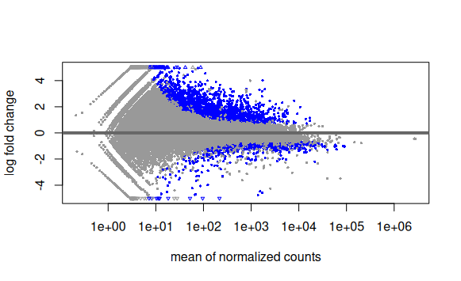

This plot shows how gene expression changes relate to average expression levels.

Most genes have similar expression levels between the two experimental groups, TD and ASD. Since the grey points are centered around 0 means there is no systematic bias toward one condition. It seems to be more significant upregulated genes than downregulated ones, although there are both.

**PCA Plot**

`{r} # PCA plot png(file="~/Documents/TDvsASD/DifExpress/PCAplot.png") vsd <- vst(dds, blind = FALSE) plotPCA(vsd, intgroup = "type") dev.off()`

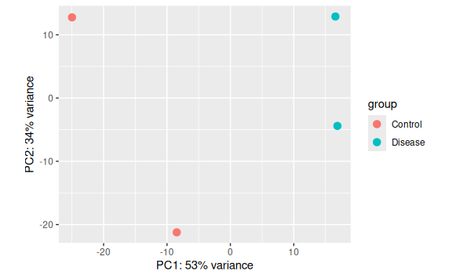

Principal Component Analysis (PCA) reduces the whole expression data into a few principal components that explain most of the variation between samples. **PC1 (53%)** explains the largest source of variation. **PC2 (34%)** explains the second largest source of variation.

PC1 separates the two groups, left (controls) from the right (disease). The plot shows that the disease status is the major source of variation. Basically, gene expression profiles differ between the control and disease groups. Which is what we would expect in a differential expression study.

However, PC2 is showing variation within each group

Notice that: one control is high on PC2, one control is low on PC2, while the same pattern occurs for the disease samples. Which suggests PC2 is capturing within-group variability.Since both groups show a similar spread along PC2, there is no indication that this variation is specific to one group.

However, since there is only two biological replicates per group, it’s difficult to estimate biological variability accurately.

**QC inspection**

`{r} # Variance stabilizing transformation vsd <- vst(dds, blind = FALSE) plotDispEsts(dds)`

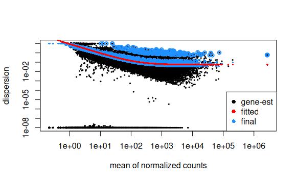

This plot shows gene-to-gene variability (dispersion) changes with expression level. In the graph it is shown that dispersion decreases as expression increases. The blue points follow the fitted trend. The blue points above the red curve may represent higher biological variability than expected suggesting genuinely variable genes.

this dispersion plot indicates that the statistical assumptions of DESeq2 are reasonably met. Even after the small sample size, the RNA-seq data are of sufficient quality for downstream differential expression analysis.

**Sample to Sample distance**

`{r} sampleDists <- dist(t(assay(vsd))) pheatmap(as.matrix(sampleDists), clustering_distance_rows = sampleDists, clustering_distance_cols = sampleDists, main = "Sample-to-Sample Distances")`

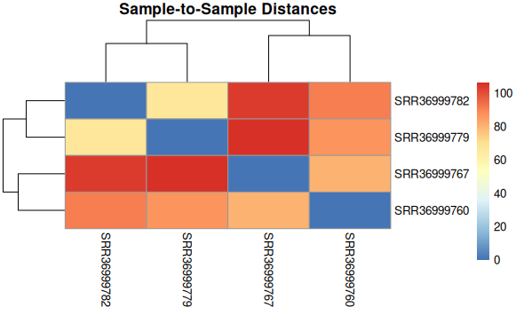

The heatmap shows

- *ASD =SRR36999782 and* SRR36999779
- *TD =SRR36999767 and* SRR36999760

The graph shows that samples within the same biological group are more similar to each other.While they are more different between experimental groups. Disease status appears to be the main source of variation in the dataset. However, With only two biological replicates per condition, the statistical power to detect differential expression is limited.

**Differential Expression Analysis**

Volcano plot

```{r} # Convert DESeqResults to data frame res_df <- as.data.frame(res)

# Add gene names

res_df$gene <- rownames(res_df)

# Remove NA values

res_df <- res_df[!is.na(res_df$padj), ]

# Define significance categories

res_df <- res_df %>% mutate( significant = case_when( log2FoldChange > 1 & padj < 0.05 ~ “Upregulated”, log2FoldChange < -1 & padj < 0.05 ~ “Downregulated”, TRUE ~ “Not significant” ),

```
# Label only extreme/peripheral genes
label = ifelse(
  abs(log2FoldChange) > 3 &
    -log10(padj) > 10,
  gene,
  NA
)
```

)

# Volcano plot

ggplot(res_df, aes(x = log2FoldChange, y = -log10(padj), color = significant)) +

geom_point(alpha = 0.7) +

geom_text_repel( data = subset(res_df, !is.na(label)), aes(label = label), size = 3, max.overlaps = Inf ) +

scale_color_manual(values = c( “Upregulated” = “red”, “Downregulated” = “blue”, “Not significant” = “grey70” )) +

theme_minimal() +

labs( title = “Volcano Plot”, x = “Log2 Fold Change”, y = “-Log10 Adjusted p-value” )

[output not shown]

[figure not shown]

This graph depicts how disease replicate 1 and 2 look very similar. At the same time, the control replicates 1 and 2 are also close between them. There are no obvious outlier samples.

Overall, the heatmap suggest that the data quality is good and that there are biologically meaningful expression differences between the two groups. However, due to the limited number of replicates, any interpretation given here provides poor estimate of real biological variability and has limited statistical representation. Likely, this example could only reflect very large, consistent expression changes.

# Gene Ontology Analysis

Once we have the main genes that are significantly up-regulated and down-regulated, we can perform gene ontology analysis. This Analysis will let us know what biological pathways, cell structures, and molecular functions are over-represented in my data.

```{r} library(clusterProfiler) library(org.Hs.eg.db) library(ggplot2) library(pheatmap) library(ggplot2) library(ggrepel) library(dplyr) library(DESeq2) #Uploading the gene_list I obtained from deseq2 geneList <-read.csv(“gene_list.csv”, header = FALSE)  
genes <- as.character(geneList$V1) head(genes) sum(genes %in% keys(org.Hs.eg.db, keytype = "SYMBOL")) # remove suffixes like _1, _2, etc. genes <- sub("_.*$“,”“, genes)

# remove duplicates

genes <- unique(genes)

mapped <- AnnotationDbi::select( org.Hs.eg.db, keys = genes, keytype = “SYMBOL”, columns = “ENTREZID” )

mapped <- mapped[!is.na(mapped$ENTREZID), ]

entrez_genes <- unique(mapped$ENTREZID)

ego <- enrichGO( gene = entrez_genes, OrgDb = org.Hs.eg.db, keyType = “ENTREZID”, ont = “BP”, pAdjustMethod = “BH”, pvalueCutoff = 0.05, qvalueCutoff = 0.05 )

head(as.data.frame(ego)) dotplot(ego, showCategory =20, color = “pvalue”)

[output not shown]

[figure not shown]

Many differentially expressed genes encode proteins often involved in: cell-cell communication, receptor signaling, immune recognition, and interactions with the extracellular environment.

Also, many significant terms relate to neutrophils, cells that are involved in: inflammation, antimicrobial defense, degranulation, innate immunity.

It is also shown many muscle-associated cellular components, including myofibrils and contractile muscle fibers, was also observed. However, these terms may be driven by a small number of differentially expressed structural genes.

**GO Molecular Function**

`{r} go_enrich_MF <- enrichGO( gene = entrez_genes, OrgDb = org.Hs.eg.db, keyType = "ENTREZID", ont = "MF", pAdjustMethod = "BH", pvalueCutoff = 0.5, qvalueCutoff = 0.5 ) dotplot(go_enrich_MF, showCategory =20, color = "pvalue") go_enrich_MF <- pairwise_termsim(go_enrich_MF) emapplot(go_enrich_MF, showCategory = 20)`

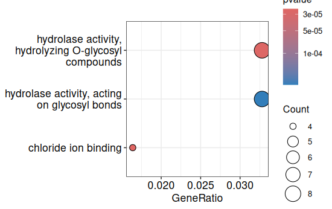

[figure not shown]

The two strongest enriched terms are enzymes that cleave carbohydrate-containing molecules. Connecting this details with the previous finding, the immune cells— neutrophils and macrophages—contain many hydrolases in their granules. These enzymes are released during immune responses and are involved in degrading pathogens and remodeling extracellular material.

**KEGG Analysis**

This step is to identify the biological pathways, functions associated with the significant genes previously obtained.

```{r} #perform Pathway enrichment analysis kegg_enrich <- enrichKEGG(gene = entrez_genes, organism = ‘hsa’, pvalueCutoff = 0.1) barplot(kegg_enrich, showCategory = 20)

```

**KEGG pathway enrichment**

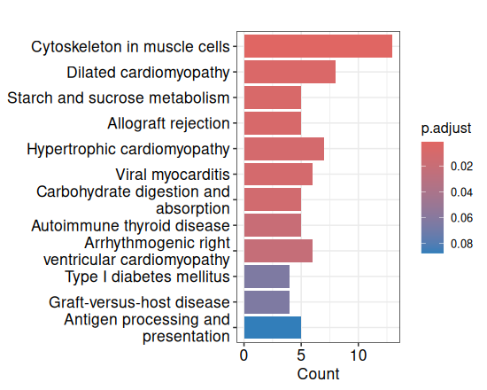

These pathways all include genes encoding structural and contractile proteins,all immune-related pathways share many immune genes, particularly those involved in antigen presentation. Enzymes involved in carbohydrate metabolism and glycosidic bond cleavage. putative enriched biological themes rather than definitive disease mechanisms.

**Conclusion**

The purpose of this project was to exemplify the steps to perform RNAseq data analysis. The results of this study are exploratory, non-definitive nor validated.

Although the present analysis findings were broadly consistent, the identified biological themes differed from those reported in the original study.

**Disclaimer**

This repository is intended for educational and reproducible research purposes. The RNA-seq data were generated by the authors of the cited publication and obtained from a public repository. The code demonstrates a standard RNA-seq analysis workflow, including quality control, differential expression analysis, and functional enrichment. Biological interpretations presented here are illustrative and should not be considered a reproduction of the original study’s conclusions.